Code for Term Project DSC 530-T301

By: Samuel Castro

03/04/2023

Referencing: ThinkStats Exploratory Data Analysis by Allen B. Downey 2nd Edition

```python
import pandas as pd
from thinkstats2 import Mean, MeanVar, Var, Std, Cov
```

```python
dataset = pd.read_csv("~/desktop/DSC520/Sleep_Efficiency.csv")
```

```python
dataset.head()
```

|  | ID | Age | Gender | Bedtime | Wakeup time | Sleep duration | Sleep efficiency | REM sleep percentage | Deep sleep percentage | Light sleep percentage | Awakenings | Caffeine consumption | Alcohol consumption | Smoking status | Exercise frequency |
| --- | --- | --- | --- | --- | --- | --- | --- | --- | --- | --- | --- | --- | --- | --- | --- |
| 0 | 1 | 65 | Female | 2021-03-06 01:00:00 | 2021-03-06 07:00:00 | 6.0 | 0.88 | 18 | 70 | 12 | 0.0 | 0.0 | 0.0 | Yes | 3.0 |
| 1 | 2 | 69 | Male | 2021-12-05 02:00:00 | 2021-12-05 09:00:00 | 7.0 | 0.66 | 19 | 28 | 53 | 3.0 | 0.0 | 3.0 | Yes | 3.0 |
| 2 | 3 | 40 | Female | 2021-05-25 21:30:00 | 2021-05-25 05:30:00 | 8.0 | 0.89 | 20 | 70 | 10 | 1.0 | 0.0 | 0.0 | No | 3.0 |
| 3 | 4 | 40 | Female | 2021-11-03 02:30:00 | 2021-11-03 08:30:00 | 6.0 | 0.51 | 23 | 25 | 52 | 3.0 | 50.0 | 5.0 | Yes | 1.0 |
| 4 | 5 | 57 | Male | 2021-03-13 01:00:00 | 2021-03-13 09:00:00 | 8.0 | 0.76 | 27 | 55 | 18 | 3.0 | 0.0 | 3.0 | No | 3.0 |

```python
dataset.columns
```

```
Index(['ID', 'Age', 'Gender', 'Bedtime', 'Wakeup time', 'Sleep duration',
       'Sleep efficiency', 'REM sleep percentage', 'Deep sleep percentage',
       'Light sleep percentage', 'Awakenings', 'Caffeine consumption',
       'Alcohol consumption', 'Smoking status', 'Exercise frequency'],
      dtype='object')
```

```python
import thinkplot
import thinkstats2
import numpy as np
```

Histograms of all the 5 variables with the mean, mode, spread, and tails

Histogram #1 Sleep Duration

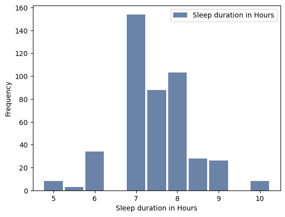

```
Mean: 7.46570796460177
```

```python
hist = thinkstats2.Hist(dataset["Sleep duration"],label = 'Sleep duration in Hours')
thinkplot.Hist(hist)
thinkplot.Show(xlabel = 'Sleep duration in Hours', ylabel = 'Frequency')
print("Mean:",Mean(dataset["Sleep duration"]))
```

Histogram #2 Sleep Effiency

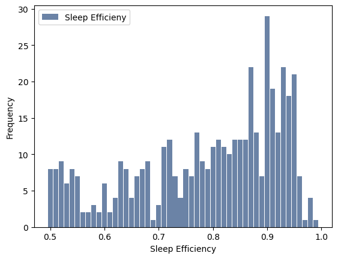

```
Mean: 0.7889159292035401
```

```python
hist = thinkstats2.Hist(dataset["Sleep efficiency"],label = 'Sleep Efficieny')
thinkplot.Hist(hist)
thinkplot.Show(xlabel = 'Sleep Efficiency', ylabel = 'Frequency')
print("Mean:",Mean(dataset["Sleep efficiency"]))
```

Histogram #3 REM Sleep Percentage

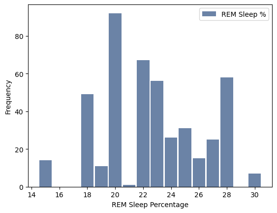

```
Mean: 22.615044247787612
```

```python
hist = thinkstats2.Hist(dataset["REM sleep percentage"],label = 'REM Sleep %')
thinkplot.Hist(hist)
thinkplot.Show(xlabel = 'REM Sleep Percentage', ylabel = 'Frequency')
print("Mean:",Mean(dataset["REM sleep percentage"]))
```

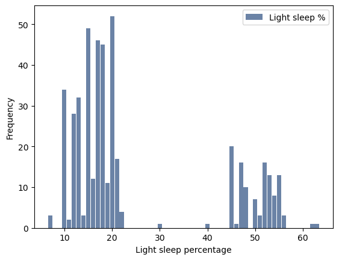

```
Mean: 24.561946902654867
```

```python
hist = thinkstats2.Hist(dataset["Light sleep percentage"],label = 'Light sleep %')
thinkplot.Hist(hist)
thinkplot.Show(xlabel = 'Light sleep percentage', ylabel = 'Frequency')
print("Mean:",Mean(dataset["Light sleep percentage"]))
```

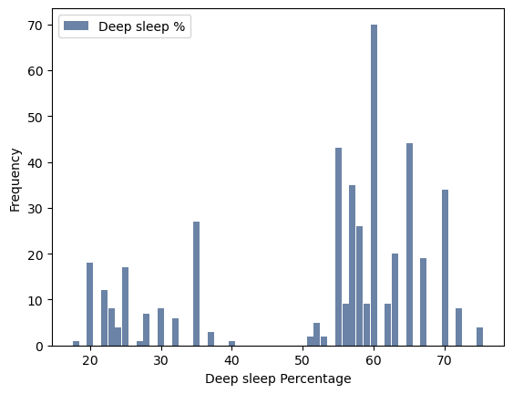

```
Mean: 52.823008849557525
```

```python
hist = thinkstats2.Hist(dataset["Deep sleep percentage"],label = 'Deep sleep %')
thinkplot.Hist(hist)
thinkplot.Show(xlabel = 'Deep sleep Percentage', ylabel = 'Frequency')
print("Mean:",Mean(dataset["Deep sleep percentage"]))
```

2 Scenarios with PMF: Scenario is Males Vs Females Sleep Duration

```python
dataset1 = dataset[dataset['Gender'] == 'Female']
dataset2 = dataset[dataset['Gender'] == 'Male']
```

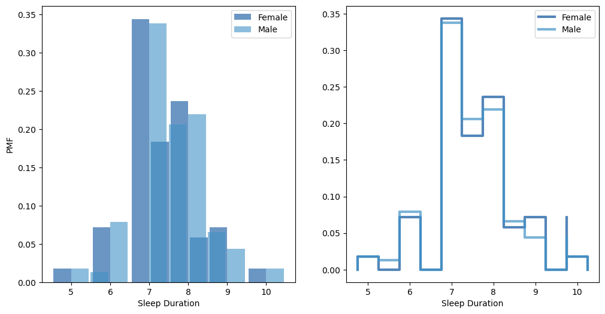

```python
Females = thinkstats2.Pmf(dataset1["Sleep duration"], label="Female")
Males = thinkstats2.Pmf(dataset2["Sleep duration"], label="Male")

thinkplot.PrePlot(2, cols=2)
thinkplot.Hist(Females, align="right")
thinkplot.Hist(Males, align="left")
thinkplot.Config(xlabel="Sleep Duration", ylabel="PMF")

thinkplot.PrePlot(2)
thinkplot.SubPlot(2)
thinkplot.Pmfs([Females, Males])
thinkplot.Config(xlabel="Sleep Duration")
```

CDF with One of my variables: I chose deep sleep percentage to show the significance of this variable.

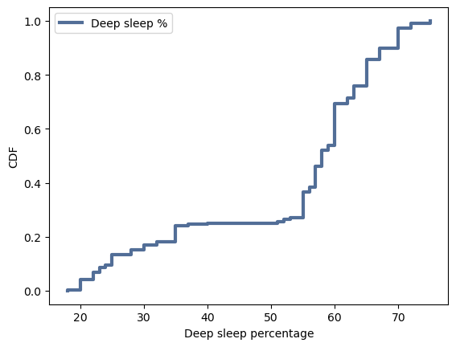

```python
cdf = thinkstats2.Cdf(dataset["Deep sleep percentage"], label='Deep sleep %')
thinkplot.Cdf(cdf)
thinkplot.Config(xlabel="Deep sleep percentage", ylabel='CDF', loc='upper left')
```

```python
cdf.Prob(50)
```

```
0.25
```

Only 25% of sleeps have a deep sleep percentage of less than or equal to 50% (Top)

Analytical Distribution: Plotting the complementary CDF and Lognormal Distribution of Deep Sleep (Bottom)

First a normal CDF Curve

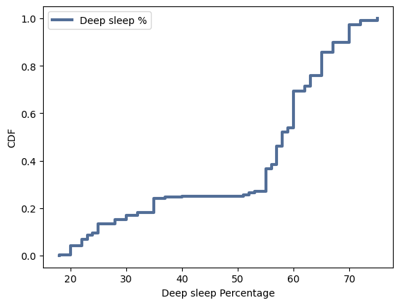

```python
cdf = thinkstats2.Cdf(dataset["Deep sleep percentage"], label='Deep sleep %')
thinkplot.Cdf(cdf)
thinkplot.Config(xlabel="Deep sleep Percentage", ylabel='CDF', loc='upper left')
```

Next is the Complementary CDF

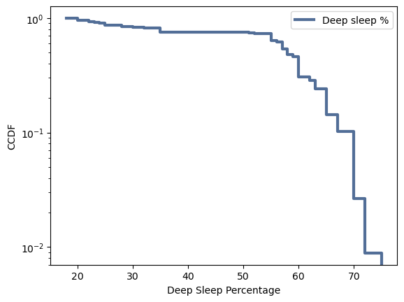

```python
thinkplot.Cdf(cdf, complement=True)
thinkplot.Config(
    xlabel="Deep Sleep Percentage",
    ylabel="CCDF",
    yscale="log",
    loc="upper right",
)
```

Lognormal Distribution Curve

```python
DeepSleep = dataset["Deep sleep percentage"]
SleepDuration = dataset["Sleep duration"]
REMSleep = dataset["REM sleep percentage"]
```

```python
def MakeNormalModel(DeepSleep):
    """Plots a CDF with a Normal model.

    weights: sequence
    """
    cdf = thinkstats2.Cdf(DeepSleep, label="weights")

    mean, var = thinkstats2.TrimmedMeanVar(DeepSleep)
    std = np.sqrt(var)
    print("n, mean, std", len(DeepSleep), mean, std)

    xmin = mean - 4 * std
    xmax = mean + 4 * std

    xs, ps = thinkstats2.RenderNormalCdf(mean, std, xmin, xmax)
    thinkplot.Plot(xs, ps, label="model", linewidth=4, color="0.8")
    thinkplot.Cdf(cdf)
```

Linear Scale

```
n, mean, std 452 52.92342342342342 15.312318864263922
```

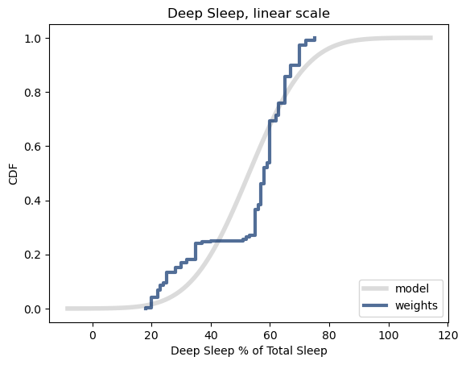

```python
MakeNormalModel(DeepSleep)
thinkplot.Config(
    title="Deep Sleep, linear scale",
    xlabel="Deep Sleep % of Total Sleep",
    ylabel="CDF",
    loc="lower right",
)
```

Log Scale

```
n, mean, std 452 1.698445835007287 0.160872410550979
```

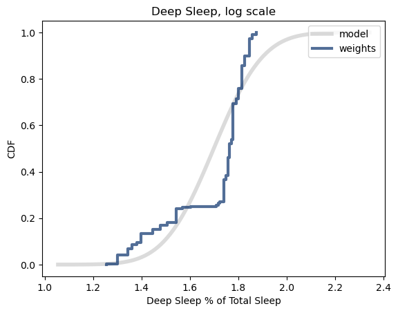

```python
log_DeepSleep = np.log10(DeepSleep)
MakeNormalModel(log_DeepSleep)
thinkplot.Config(
    title="Deep Sleep, log scale",
    xlabel="Deep Sleep % of Total Sleep",
    ylabel="CDF",
    loc="upper right",
)
```

ScatterPlots Comparing 2 variables: Sleep Duration and Deep Sleep - Sleep Duration and REM Sleep %

```python
def Jitter(values, jitter=0.5):
    n = len(values)
    return np.random.normal(0, jitter, n) + values
```

```python
DeepSleep = Jitter(DeepSleep, 1.3)
SleepDuration = Jitter(SleepDuration, 0.5)
REMSleep  = Jitter(REMSleep , 0.7)
```

Sleep Duration vs Deep Sleep

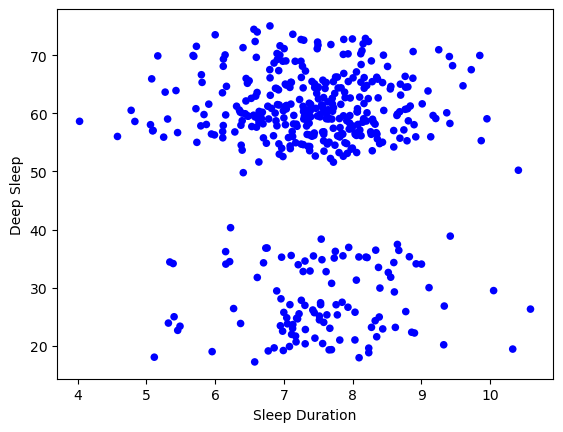

```python
thinkplot.Scatter(SleepDuration, DeepSleep, alpha=1.0)
thinkplot.Config(xlabel='Sleep Duration',
                 ylabel='Deep Sleep',
                 legend=False)
```

Sleep Duration vs REM Sleep %

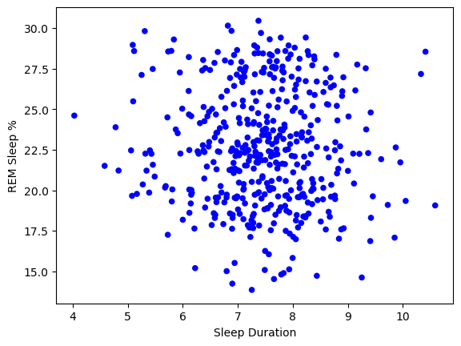

```python
thinkplot.Scatter(SleepDuration, REMSleep , alpha=1.0)
thinkplot.Config(xlabel='Sleep Duration',
                 ylabel='REM Sleep %',
                 legend=False)
```

Conducting a test on my hypothesis:

```python
class HypothesisTest(object):

    def __init__(self, data):
        self.data = data
        self.MakeModel()
        self.actual = self.TestStatistic(data)

    def PValue(self, iters=1000):
        self.test_stats = [self.TestStatistic(self.RunModel())
                           for _ in range(iters)]

        count = sum(1 for x in self.test_stats if x >= self.actual)
        return count / iters

    def TestStatistic(self, data):
        raise UnimplementedMethodException()

    def MakeModel(self):
        pass

    def RunModel(self):
        raise UnimplementedMethodException()
```

```python
class CorrelationPermute(thinkstats2.HypothesisTest):

    def TestStatistic(self, data):
        xs, ys = data
        test_stat = abs(thinkstats2.Corr(xs, ys))
        return test_stat

    def RunModel(self):
        xs, ys = self.data
        xs = np.random.permutation(xs)
        return xs, ys
```

```python
data = SleepDuration, DeepSleep
HypoTest = CorrelationPermute(data)
pvalue = HypoTest.PValue()
pvalue
```

```
0.213
```

```python
def LeastSquares(xs, ys):
    meanx, varx = MeanVar(xs)
    meany = Mean(ys)

    slope = Cov(xs, ys, meanx, meany) / varx
    inter = meany - slope * meanx

    return inter, slope
```

```python
LeastSquares(SleepDuration, DeepSleep)
```

```
(59.804881819889594, -0.9263574429639483)
```